# CRB Variance

Brian

6/14/2022

# Disclaimer

*This work is very preliminary as I get back into the coding swing of things. Data wrangling and figure generation will be done via R, but the rest of the project will be done using good ol’ microsoft products. This is just an entry point into data crunching and should by no means be considered a final product.*

# Steamboat Tower SNOTEL

## Raw data download

### Steamboat Tower (825) SNOTEL data

```r
# The fucntion snotel_download evidently downloads everything in metric units.

snotel_825_tower <- snotel_download(site_id = 825, path = tempdir('../data'), internal = TRUE)
```

```
## Error in wdman::phantomjs(verbose = FALSE) :
##   PhantomJS signals port = 4567 is already in use.
```

```r
write.csv(snotel_825_tower,"C:/Users/13074/Documents/ESS580/thesis_project/thesis_research/data_raw/snotel_825.csv", row.names = FALSE) #write in the raw data
```

### Data Cleaning

```r
head(snotel_825_tower) # check the date, usually a character.
```

```
##   network state site_name               description      start        end
## 1    SNTL    CO    tower  Fish Creek (140500010407) 1978-10-01 2022-06-15
## 2    SNTL    CO    tower  Fish Creek (140500010407) 1978-10-01 2022-06-15
## 3    SNTL    CO    tower  Fish Creek (140500010407) 1978-10-01 2022-06-15
## 4    SNTL    CO    tower  Fish Creek (140500010407) 1978-10-01 2022-06-15
## 5    SNTL    CO    tower  Fish Creek (140500010407) 1978-10-01 2022-06-15
## 6    SNTL    CO    tower  Fish Creek (140500010407) 1978-10-01 2022-06-15
##   latitude longitude elev county site_id       date snow_water_equivalent
## 1    40.54   -106.68 3237  Routt     825 1979-08-13                    NA
## 2    40.54   -106.68 3237  Routt     825 1979-08-14                    NA
## 3    40.54   -106.68 3237  Routt     825 1979-08-15                    NA
## 4    40.54   -106.68 3237  Routt     825 1979-08-16                    NA
## 5    40.54   -106.68 3237  Routt     825 1979-08-17                    NA
## 6    40.54   -106.68 3237  Routt     825 1979-08-18                    NA
##   precipitation_cumulative temperature_max temperature_min temperature_mean
## 1                      841              NA              NA               NA
## 2                      861              NA              NA               NA
## 3                       NA              NA              NA               NA
## 4                       NA              NA              NA               NA
## 5                       NA              NA              NA               NA
## 6                       NA              NA              NA               NA
##   precipitation
## 1            20
## 2            NA
## 3            NA
## 4            NA
## 5            NA
## 6            NA
```

```r
snotel_825_tower$Date <- as.Date(snotel_825_tower$date) #change date from character to date format, capitalize to work with Water year functon from NWIS.

snotel_825_clean <- snotel_825_tower %>% # filter for the timeframe
  filter(Date >= "1978-10-01" & Date <= "2021-08-31") %>%
  filter(temperature_mean >= -30 & temperature_mean <= 20) %>% # removing outliers
  addWaterYear() %>%
  mutate(daymonth = format(as.Date(Date), "%d-%m")) %>%
  na.omit()
```

##### adding water day using difftime (SUPER COOL. example from [this](https://stackoverflow.com/questions/48123049/create-day-index-based-on-water-year))

```r
#adding water day using difftime (SUPER COOL. example from [this](https://stackoverflow.com/questions/48123049/create-day-index-based-on-water-year))

snotel_825_clean <- snotel_825_clean %>%
  group_by(waterYear)%>%
  mutate(waterDay = (as.integer(difftime(Date, ymd(paste0(waterYear - 1 ,'-09-30')), units = "days"))))


write.csv(snotel_825_clean,"C:/Users/13074/Documents/ESS580/thesis_project/thesis_research/data_clean/snotel_825_clean.csv", row.names = FALSE)
```

### Figure check

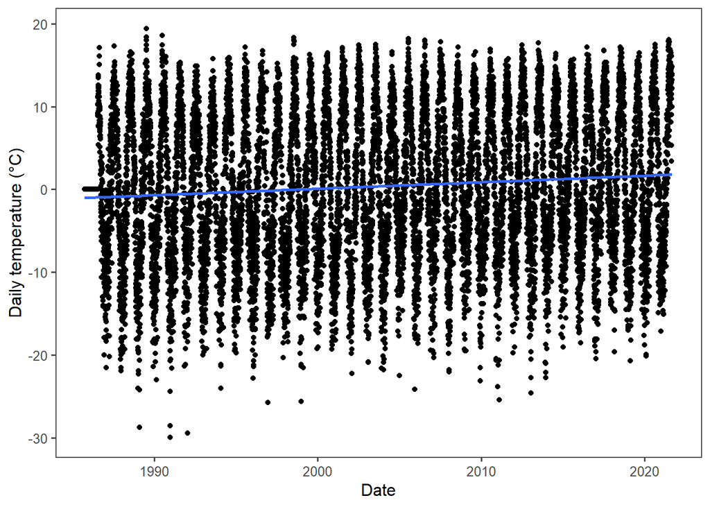

```r
ggplot(snotel_825_clean, aes(x = Date, y = temperature_mean, filter(waterYear = 1990))) +
  geom_point() + #lwd = 2) +
  theme_few() +
  geom_smooth(method = "lm", se=FALSE) +
  ylab('Daily temperature (°C)') +
  xlab('Date')
```

```r
#Check for outliers....

#dygraph

temp_xts <- xts(snotel_825_clean$temperature_mean, order.by = snotel_825_clean$Date)

dygraph(temp_xts) %>%
  dyAxis("y", label = "Daily temperature (°C)")
```

[interactive chart not shown]

## Detrending Data

```r
#SF figured out the yearly average by water year

#average water year temperature

yearly_wy_aver <- snotel_825_clean %>%
  group_by(waterYear) %>%
  mutate(aver_ann_temp = mean(temperature_mean))
```

```r
#Average temperature by day for all water years:

daily_wy_aver <- yearly_wy_aver %>%
  group_by(daymonth) %>%
  mutate(aver_day_temp = mean(aver_ann_temp))

#average mean temperature by day for the period of record:

daily_wy_aver <- daily_wy_aver %>%
  group_by(daymonth) %>%
  mutate(all_ave_temp = mean(daily_wy_aver$aver_day_temp))

#str(daily_wy_aver)
```

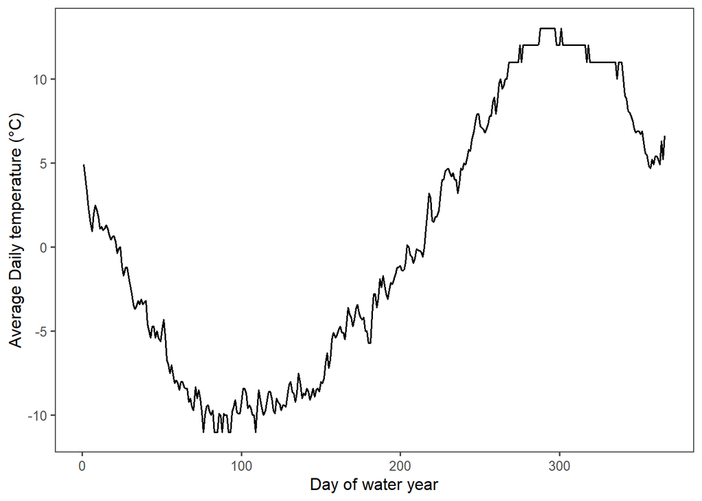

```r
# try to show all years as means.
daily_wy_aver2 <- daily_wy_aver %>%
  #filter(waterYear == "1987" | waterYear == "2021") %>%
  group_by(waterDay) %>%
  mutate(date_temp = mean(temperature_mean))


daily_wy_aver2$date_temp <- signif(daily_wy_aver2$date_temp,2) #reduce the sig figs



ggplot(daily_wy_aver2, aes(x = waterDay, y = date_temp))+#, color = waterYear)) +
  geom_line(size= 0.7) +
  #geom_line(aes) +
  theme_few() +
  #geom_smooth(method = "lm", se=FALSE) +
  ylab('Average Daily temperature (°C)') +
  xlab('Day of water year')
```

**Day of year average temperature for the 1987-2021 period of record for Tower SNOTEL site.**

## All years vs 1987 & 2021

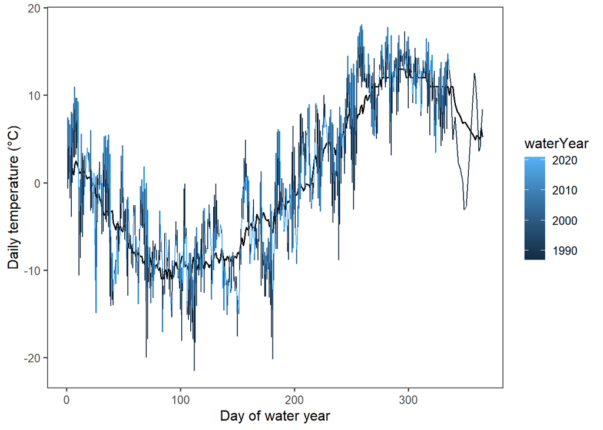

```r
# 87 and 21 only. Not useful
daily_wy_aver3 <- daily_wy_aver2 %>%
  filter(waterYear == "1987" | waterYear == "2021") %>%
  select(waterDay, waterYear, temperature_mean, daymonth, date_temp) %>%
  group_by(daymonth)

# ggplot(daily_wy_aver3, aes(x = waterDay, y = date_temp))+#, color = waterYear)) +
#   geom_line(size= 0.7) +
#   geom_line(aes(y = temperature_mean, color = waterYear)) +
#   theme_few() +
#   #geom_smooth(method = "lm", se=FALSE) +
#   #scale_colour_identity() +
#   scale_color_manual(name = "Water Year", values = c("blue", "red"))
#   ylab('Daily temperature (°C)') +
#   xlab('Day of water year')

ggplot(daily_wy_aver3) + #, color = waterYear)) +
  geom_line(aes(x = waterDay, y = date_temp), group = 1, size= 0.7) +
  geom_line(aes(x = waterDay, y = temperature_mean, group = 1, colour = waterYear)) +
  theme_few() +
  #geom_smooth(method = "lm", se=FALSE) +
  #scale_colour_identity() +

  #scale_color_manual(name = "Water Year")
  ylab('Daily temperature (°C)') +
  xlab('Day of water year')
```

```r
# ??geom_line
#
# scale_color_manual(name = "Colors",
#                      values = c("a" = "blue", "b" = "red")
#
# color_group <- c("blue","black")
#
# ?scale_discrete_identity()
```

**Day of year average temperature and daily 1987 & 2021 temperatures for the 1987-2021 period of record for Tower SNOTEL site.** *legend is bad.*

### Calculating varience

```r
#Calculating residuals, WY 1987 (first full year on record for 825)

residuals_1987 <- daily_wy_aver %>%
  group_by(waterYear) %>%
  filter(waterYear == 1987) %>%
  mutate(residual = (aver_ann_temp-all_ave_temp)+temperature_mean-aver_day_temp) %>%
  mutate(deviation = abs(residual-lag(residual)))

residuals_2021 <- daily_wy_aver %>%
  group_by(waterYear) %>%
  filter(waterYear == 2021) %>%
  mutate(residual = (aver_ann_temp-all_ave_temp)+temperature_mean-aver_day_temp) %>%
  mutate(deviation = abs(residual-lag(residual)))
```

## Figures

### 1987

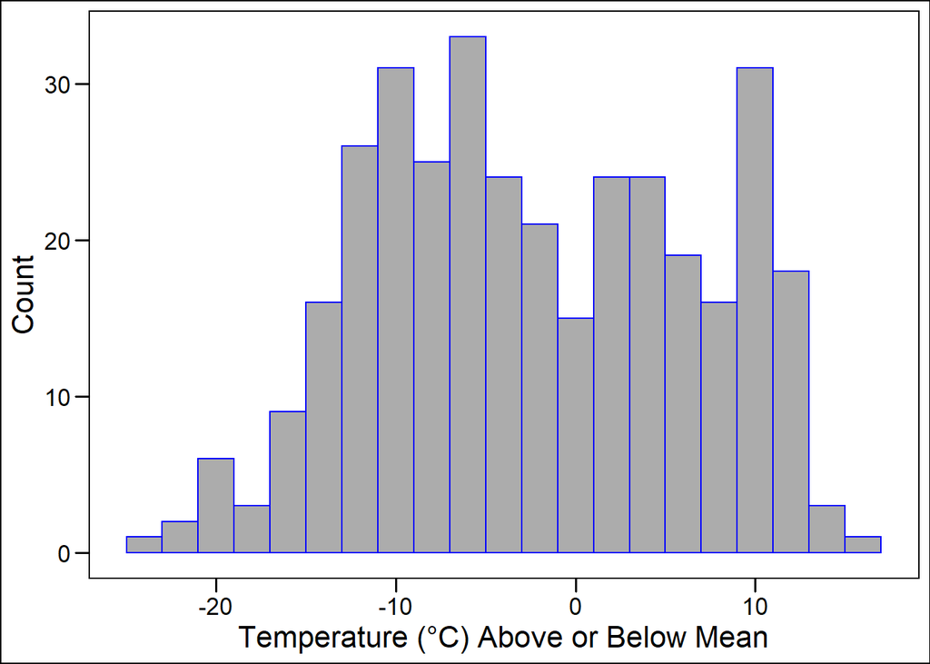

```r
ggplot(residuals_1987, aes(residual)) +
  geom_histogram(alpha = 0.5, color = "blue", bins = 15, binwidth = 2) +
  theme_base() +
  xlab("Temperature (°C) Above or Below Mean") +
  ylab("Count")
```

**Distribution of daily temperature variance for 1987 compared to the 1987-2021 period of record.**

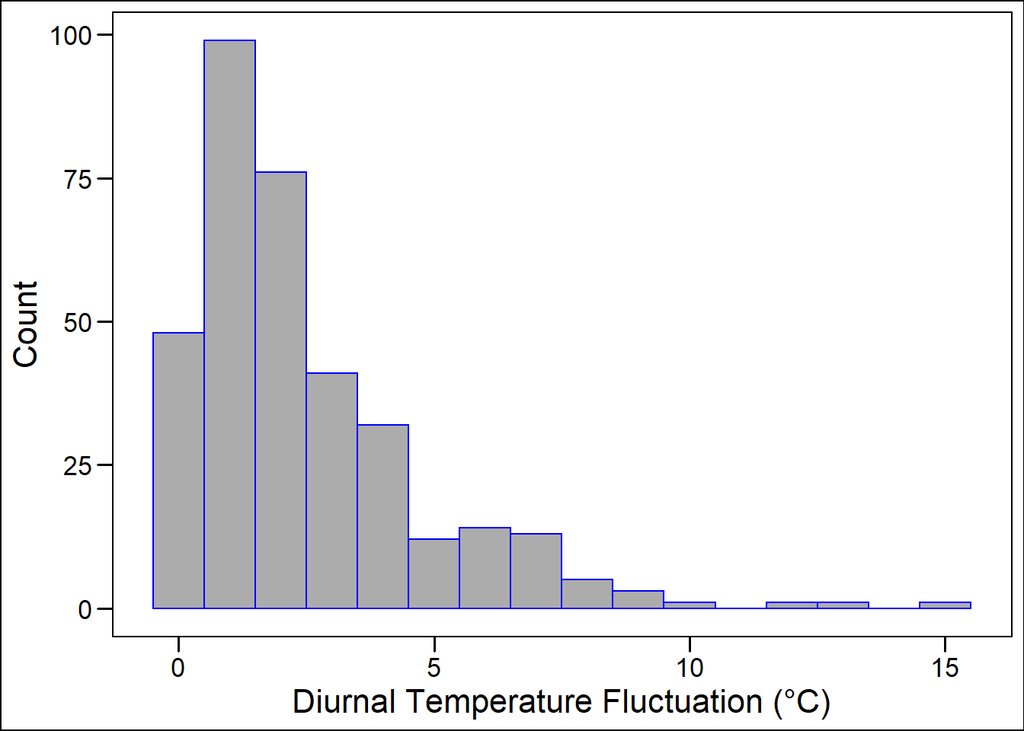

```r
ggplot(residuals_1987, aes(deviation)) +
geom_histogram(alpha = 0.5, color = "blue", bins = 15, binwidth = 1) +
  scale_x_continuous(breaks = seq(0, 15, by=5)) +
  theme_base() +
  xlab("Diurnal Temperature Fluctuation (°C)") +
  ylab("Count")
```

**Distribution of 1987 diurnal temperature fluctuation from the 1987-2021 period of record.**

```r
sum(residuals_1987$deviation, na.rm = TRUE)
```

```
## [1] 865.0682
```

```r
865.0682
```

```
## [1] 865.0682
```

```r
residuals_1987 <- residuals_1987 %>%
  mutate(prcnt = deviation/865.0682*100)

sum(residuals_1987$prcnt, na.rm = TRUE)
```

```
## [1] 100
```

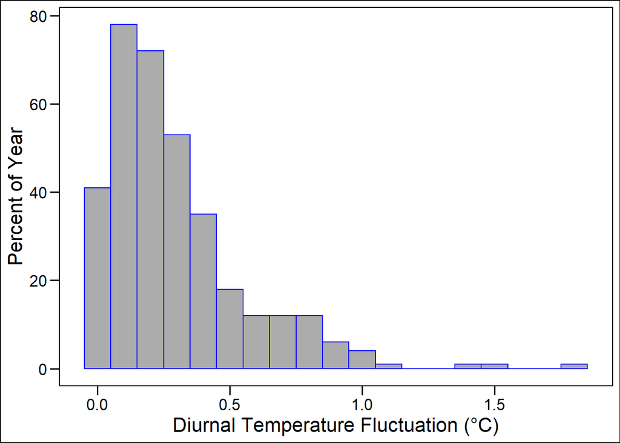

```r
ggplot(residuals_1987, aes(prcnt)) +
geom_histogram(alpha = 0.5, color = "blue", bins = 15, binwidth = 0.1) +
  #scale_x_continuous(breaks = seq(0, 15, by=5)) +
  theme_base() +
  xlab("Diurnal Temperature Fluctuation (°C)") +
  ylab("Percent of Year")
```

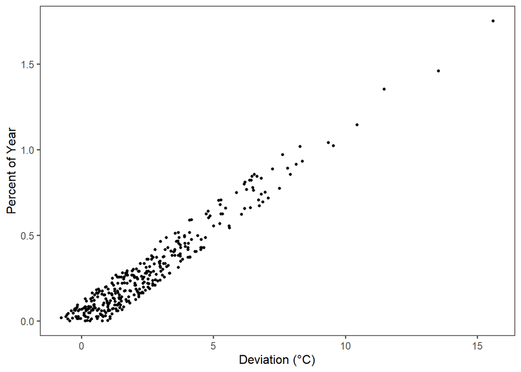

```r
ggplot(residuals_1987) + #, color = waterYear)) +
  geom_jitter(aes(x = deviation, y = prcnt), width = 1, size=1) +
  theme_few() +
  #geom_smooth(method = "lm", se=FALSE) +
  #scale_colour_identity() +
  #scale_color_manual(name = "Water Year")
  ylab('Percent of Year') +
  xlab('Deviation (°C)')
```

**Percent of year 1987 for the deviation. This… doesn’t look right.**

### 2021

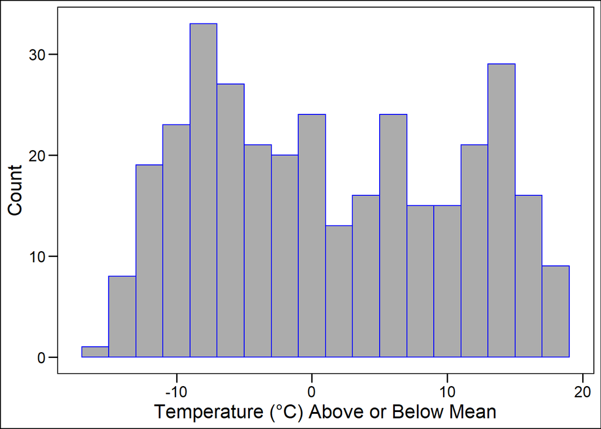

```r
ggplot(residuals_2021, aes(residual)) +
  geom_histogram(alpha = 0.5, color = "blue", binwidth = 2) +
  theme_base() +
  xlab("Temperature (°C) Above or Below Mean") +
  ylab("Count")
```

**Distribution of daily temperature variance for 2021 compared to the 1987-2021 period of record.**

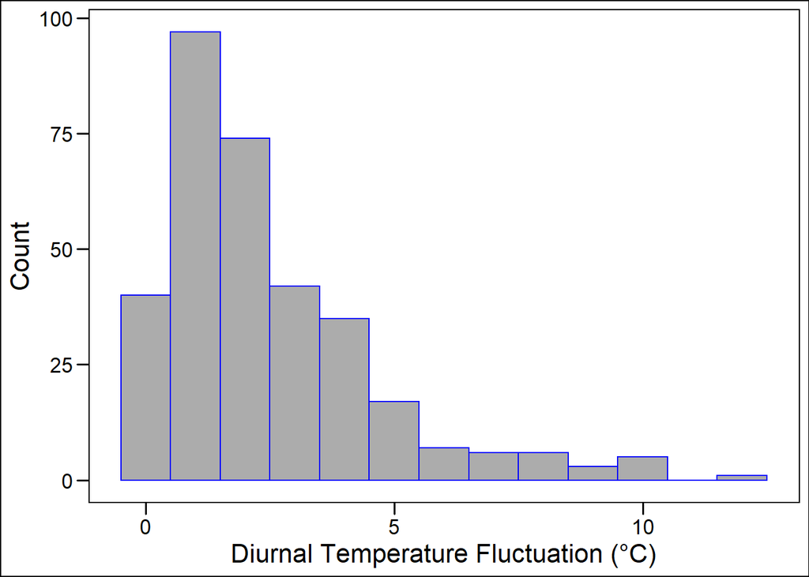

```r
ggplot(residuals_2021, aes(deviation)) +
  geom_histogram(alpha = 0.5, color = "blue", bins = 15, binwidth = 1) +
  scale_x_continuous(breaks = seq(0, 15, by=5)) +
  theme_base() +
  xlab("Diurnal Temperature Fluctuation (°C)") +
  ylab("Count")
```

```r
#
# ggplot(residuals_2021, aes(deviation)) +
# geom_histogram(binwidth=1,
#                  center = 6,
#                  aes(col=I("blue"))) +
#   scale_x_continuous(breaks = seq(0, 15, by=5))
#   scale_x_continuous(breaks=seq(1,max(residuals_2021$deviation) + 1, by = 2))
```

**Distribution of 2021 diurnal temperature fluctuation from the 1987-2021 period of record.** *Scale not the same as 1987*

```r
sum(residuals_2021$deviation, na.rm = TRUE)
```

```
## [1] 832.3876
```

```r
# 832.3876

residuals_2021 <- residuals_2021 %>%
  mutate(prcnt = deviation/832.3876*100)

sum(residuals_2021$prcnt, na.rm = TRUE)
```

```
## [1] 100
```

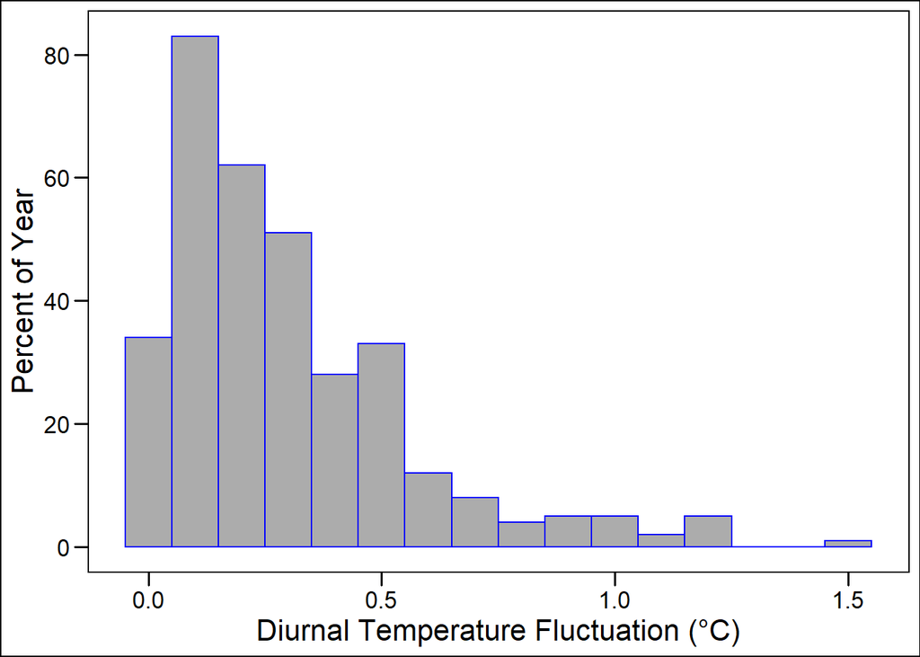

```r
ggplot(residuals_2021, aes(prcnt)) +
geom_histogram(alpha = 0.5, color = "blue", bins = 15, binwidth = 0.1) +
  #scale_x_continuous(breaks = seq(0, 15, by=5)) +
  theme_base() +
  xlab("Diurnal Temperature Fluctuation (°C)") +
  ylab("Percent of Year")
```

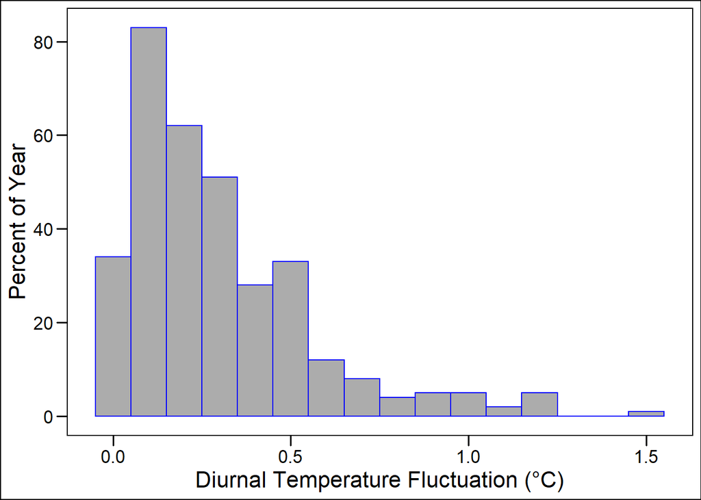

```r
# This looks weird. Maybe a scatter plot is more appropriate.

ggplot(residuals_2021, aes(prcnt)) +
geom_histogram(alpha = 0.5, color = "blue", bins = 15, binwidth = 0.1) +
  #scale_x_continuous(breaks = seq(0, 15, by=5)) +
  theme_base() +
  xlab("Diurnal Temperature Fluctuation (°C)") +
  ylab("Percent of Year")
```

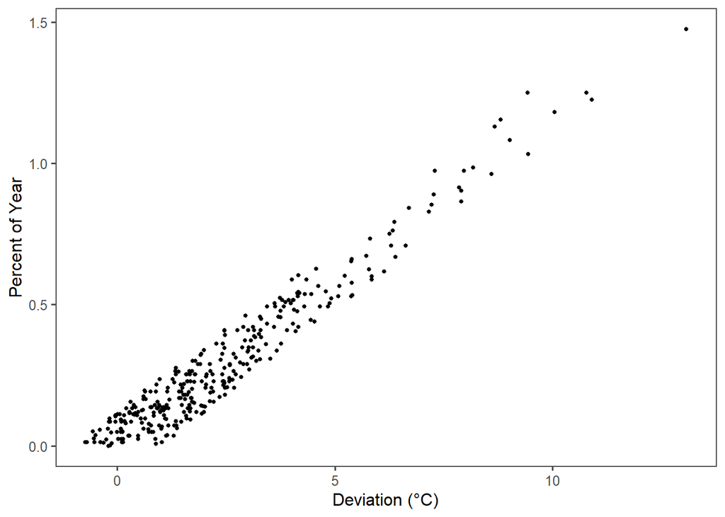

```r
ggplot(residuals_2021) + #, color = waterYear)) +
  geom_jitter(aes(x = deviation, y = prcnt), width = 1, size=1) +
  theme_few() +
  #geom_smooth(method = "lm", se=FALSE) +
  #scale_colour_identity() +
  #scale_color_manual(name = "Water Year")
  ylab('Percent of Year') +
  xlab('Deviation (°C)')
```

**Percent of year 2021 for the deviaation. This… doesn’t look right.**

# Mann-Kendall & Sen’s Slope

### Mann Kendal for Tower site daily temperatures

```r
# excluding dates where no temperature data were recorded.

str(daily_wy_aver)
```

[output not shown]

[output cut: 76 more lines]

[output not shown]

```r
daily_wy_aver4 <- daily_wy_aver2 %>%
  filter(Date > "1986-07-17")

tower_mk <- mk.test(daily_wy_aver4$temperature_mean)
print(tower_mk)
```

```
##
##  Mann-Kendall trend test
##
## data:  daily_wy_aver4$temperature_mean
## z = 10.156, n = 12499, p-value < 2.2e-16
## alternative hypothesis: true S is not equal to 0
## sample estimates:
##            S         varS          tau
## 4.731005e+06 2.169853e+11 6.066612e-02
```

### Sen’s Slope for Tower site daily temperatures

```r
tower_sens <- sens.slope(daily_wy_aver4$temperature_mean)

print(tower_sens)
```

```
##
##  Sen's slope
##
## data:  daily_wy_aver4$temperature_mean
## z = 10.156, n = 12499, p-value < 2.2e-16
## alternative hypothesis: true z is not equal to 0
## 95 percent confidence interval:
##  0.0001879699 0.0002786291
## sample estimates:
##  Sen's slope
## 0.0002328967
```

# SNOTEL Site corrections

*“The Morrissey method also shows more variations in temperature trends between sites than the Oyler method, which dampens site-to-site variability in temperature trends.*

# Next steps / Further questions

### SNOTEL

Need to investigate site specific issues related to disturbances (general SNOTEL issues). *Unsure of methods*

Having issues with day-of-year and water year interactions. This keeps me from showing mean trendlines over the whole period of record as R does not want to recognize the x axis as anything other than numerical. *Resolved*

Would using a pivot table be better when displaying temperature for 240 sites? (What data management is best for that much data?) *Doesn’t look like it’s needed currently*

How to include oscillation influence into the data?

### Beyond SNOTEL

What other data / site types do I want to include?

### Coding

I am sure Matt would tell me to automate this. Not quite sure how, but it seems likely I could find a list of SNOTEL sites and using spatial data, exclude sites not within the CRB boundary. From there, I could write a for loop & function to use the snotelr function to download data. *Jack Reuland helped with this idea below. Now what to do with the large dataframe….*

# All stations:

Per Jack’s recommendations, BUT, while there are 240 stations, I could only find 166 while clipping the NRCS SNOTEL points and a CRB polygon from CAPGISadmin. The NRCS stated the sites given were active, so perhaps there are 74 inactive sites?

```r
TableOfSNOTEL_StudyArea <- read.csv("C:/Users/13074/Desktop/MS_Watershed_Science/Literature/SNOTEL_sites_1_2.csv", header = TRUE)

studyarea_site_id <- as.vector(TableOfSNOTEL_StudyArea$site_id)

SNOTEL_StudyArea <- snotel_download(site_id = c(studyarea_site_id), internal = TRUE)
```

```
## Error in wdman::phantomjs(verbose = FALSE) :
##   PhantomJS signals port = 4567 is already in use.
```

```r
write.csv(SNOTEL_StudyArea,"C:/Users/13074/Documents/ESS580/thesis_project/thesis_research/data_raw/SNOTEL_StudyArea.csv", row.names = FALSE) #write in the raw data
```

```r
head(SNOTEL_StudyArea)
```

```
##   network state       site_name                             description
## 1    SNTL    CO elkhead divide  Headwaters Elkhead Creek (140500010601)
## 2    SNTL    CO elkhead divide  Headwaters Elkhead Creek (140500010601)
## 3    SNTL    CO elkhead divide  Headwaters Elkhead Creek (140500010601)
## 4    SNTL    CO elkhead divide  Headwaters Elkhead Creek (140500010601)
## 5    SNTL    CO elkhead divide  Headwaters Elkhead Creek (140500010601)
## 6    SNTL    CO elkhead divide  Headwaters Elkhead Creek (140500010601)
##        start        end latitude longitude elev county site_id       date
## 1 2016-09-01 2022-06-21     40.8    -107.1 2682  Routt    1252 2016-09-01
## 2 2016-09-01 2022-06-21     40.8    -107.1 2682  Routt    1252 2016-09-02
## 3 2016-09-01 2022-06-21     40.8    -107.1 2682  Routt    1252 2016-09-03
## 4 2016-09-01 2022-06-21     40.8    -107.1 2682  Routt    1252 2016-09-04
## 5 2016-09-01 2022-06-21     40.8    -107.1 2682  Routt    1252 2016-09-05
## 6 2016-09-01 2022-06-21     40.8    -107.1 2682  Routt    1252 2016-09-06
##   snow_water_equivalent precipitation_cumulative temperature_max
## 1                    NA                       NA            23.6
## 2                     0                      795            20.6
## 3                     0                      798            17.8
## 4                     0                      823            15.8
## 5                     0                      833            19.0
## 6                     0                      836            19.6
##   temperature_min temperature_mean precipitation
## 1            11.0             16.4            NA
## 2             9.8             14.1             3
## 3             8.1             11.3            25
## 4             6.8             10.9            10
## 5             6.4             12.3             3
## 6             6.4             12.3             0
```

# Coop Data

NOAA/NWS Cooperative Observer Network

Two stations near steamboat, according to this [site](https://wrcc.dri.edu/inventory/coop05.html). 057936 02 SBTC2 UNITED STATES CO ROUTT +7 STEAMBOAT SPRINGS 40 30 17 -106 51 58 6636 057942 02 SSPC2 UNITED STATES CO ROUTT +7 STEAMBOAT SPRINGS 1 W 40 29 00 -106 51 00 6700

Downloading from the [Iowa Environmental Mesonet](https://mesonet.agron.iastate.edu/request/coop/fe.phtml?network=COCLIMATE). NOAA package not working, maybe due to user error.

```r
# coops_search(station_name = 057936,product = "air_temperature") # Handy R package did not work.

coop_steamboat <- read.csv("C:/Users/13074/Documents/ESS580/thesis_project/thesis_research/data_raw/steamboat_nwscoop_1900_2022.csv", header = TRUE)
```

```r
coop_steamboat$Date <- mdy(coop_steamboat$day) #change date from character to date format, capitalize to work with Water year functon from NWIS.

coop_sb_cleanish <- coop_steamboat %>%
  addWaterYear() %>%
  mutate(daymonth = format(as.Date(Date), "%d-%m")) %>%
  na.omit()

#str(coop_steamboat)

sb_coop_temp_xts <- xts(coop_sb_cleanish$avg_T_c, order.by = coop_sb_cleanish$Date)

dygraph(sb_coop_temp_xts) %>%
  dyAxis("y", label = "Daily temperature (°C)")
```

[interactive chart not shown]

# Notes from SF, 22/6:

Some initial thoughts: 1) I assume that frequency is the raw count, i.e., number of days? At some point, a % of the year may be better; 2) COOP data, such as at Steamboat, should have a much longer period of record if you want to examine change over time - setting up the analysis is a good start; 3) there is an inconsistency with the SNOTEL data (see https://doi.org/10.1029/2019WR025921); 4) we (https://doi.org/10.1029/2002WR001512, etc.) used 240 stations (metadata at https://doi.org/10.1029/2009WR007835), and I know that are a few are inactive, but likely not 74 - some are outside of the basin (https://agupubs.onlinelibrary.wiley.com/cms/asset/2af0fc20-a948-455d-bf0e-8f6e7dcc7ad9/wrcr12217-fig-0001.png) but still representative (a few can be removed, in hindsight, like the ones in the Laramie Range).

# Notes, Monday 27/6

Figured out the water day issue and applied it to the Day of water year figures (this was an issue that I spent waaaaaay too much time on). Went the wrong way with pivot tables, day of year, and using average annual temp for the mean aily figure. Going to use Excel to check if correct. Goal for Tuesday: Determine daily percentages.

# Notes, Thursday 30/6

Need to discuss methods of identifying temperature shifts due to sensor changes.

Not sure how to show percent of days for data.